# Introduction to literate programming with Quarto

Author

Charlotte Soneson, Michael Stadler

Published

October 19, 2026

# Disclaimer

The “Introduction to literature programming with Quarto” workshop is based on Charlotte Soneson’s “Reproducible Publishing and literate programming with Quarto” available from https://csoneson.github.io/ReproduciblePublishing2024/ under a CC-BY License.

# How (many) manuscripts are made

[figure not shown]

The schematic above shows an (over-simplified, of course) illustration of the traditional process used to generate many scientific manuscripts. In order to produce such a manuscript, we collect data, run various types of analyses, generate plots and schematics, carefully assemble them into the final figures for the paper, write the text and paste the analysis results and figures in the document, before submitting to a journal for consideration.

After some time, we receive the reviewer reports, often suggesting some changes or additions to the analysis. At this point it’s up to us to (1) make sure that we still remember how the original figures and results were generated, and (2) go through the whole process above again to create the updated figures and results.

What we will talk about in this workshop is one way of structuring our work so that (1) it, arguably, becomes easier to get back into it after some time, (2) we know exactly how each original figure was created, and (3) the amount of *manual* work required to revise the manuscript is reduced. In addition, it has the advantage of automatically providing us with a reproducible record of the analysis, which can be shared for example as a supplementary file of the manuscript.

# What is literate programming?

The term ‘[literate programming](http://www.literateprogramming.com/)’ was introduced by [Donald Knuth](https://en.wikipedia.org/wiki/Donald_Knuth) in 1984, and refers to a programming paradigm where an explanation of the analysis process in natural language is interspersed with chunks of executable source code. This single source file is then used to create both machine executable code (effectively, extracting the code chunks) and a comprehensive human-readable report containing both the natural language text and the results of running the code. A recent [publication](https://academic.oup.com/bib/article/24/6/bbad375/7326135) by Ziemann et al. considers literate programming one of the five pillars of reproducible computational research:

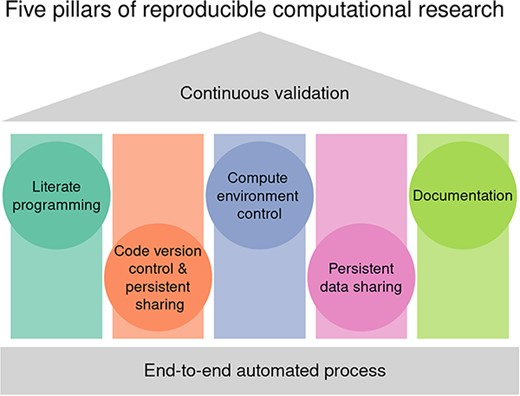

According to the same article, there are several advantages of using literate programming, including:

- since the report contains both the code and the output, we know precisely which code was executed to generate a specific result (compare this to copy-pasting your figures from the RStudio viewer into a Word document), and the text and results are arranged in a logical and consistent way. Circumventing the copy-pasting of results into reports also saves time.
- it makes it easy to provide extensive documentation and explanations of the code - in principle, we can write entire papers using literate programming!
- it provides built-in checks that the given code *actually runs* - if not, no output report is generated.
- it is easy to include a description of the used compute environment (for example the output of a session-info command that lists the versions of the interpreter and all packages), which is crucial to identify the source of possible differences that arise after an update.

# What is R Markdown?

R Markdown lets you write dynamic, reproducible documents in R (actually, it can also contain code in other languages like python or bash!). An R Markdown document can contain regular text as well as code chunks, equations and images. The document can be rendered into many different output formats, such as html, pdf, Microsoft Word, websites, and slideshows (for the latter, check out [xaringan](https://slides.yihui.org/xaringan/#1)).

# What is Quarto?

[Quarto](https://quarto.org) is an open-source publishing system built on markdown. It is developed and maintained by Posit. For R users, Quarto can be thought of as “next generation” R Markdown, combining what was previously spread across many packages (including `rmarkdown`, `bookdown`, and `xaringan`) into one system. Quarto is fundamentally multi-lingual, and can for example be used to write python code without requiring R to be present (as mentioned, R Markdown can also contain python code, but R needs to be present in order to compile the report). For a more detailed overview, see e.g. [the Quarto FAQ](https://quarto.org/docs/faq/rmarkdown.html#quarto-sounds-similar-to-r-markdown.-what-is-the-difference-and-why-create-a-new-project) or [this blog post](https://yihui.org/en/2022/04/quarto-r-markdown/). In terms of the syntax, R Markdown and Quarto are very similar, and in many cases simply changing the file extension from `.Rmd` to `.qmd` or vice versa will give a valid file.

Conceptually, Jupyter notebooks (or iPython notebooks, `.ipynb`) are also comparable to R markdown and and Quarto, in that they combine natural language, code and code outputs in a single document, although Jupyter notebooks (in contrast to `.Rmd` and `.qmd` files, which are both extending Markdown `.md` files) are not plain text files and need a specific tool for editing. `.ipynb` can also store code output, yet without a guarantee that the code junks have been executed in order, and when used in version control systems, the complex internal structure of `.ipynb` files can lead to large, hard-to-read diffs.

In this workshop, we will use Quarto, but most of the basics that we are going to cover works perfectly fine also with R Markdown. Moreover, the main walkthrough will use R and [RStudio](https://posit.co/products/open-source/rstudio/), but pointers will be made to the corresponding steps in [Visual Studio Code](https://code.visualstudio.com/) (assuming that the latter is used for python projects).

To prepare your environment for Quarto, follow the instructions outlined in this document.

# Creating a .qmd file in RStudio

To create a Quarto document (`.qmd` file) in RStudio, click on `New File`, and select `Quarto Document` (or, equivalently, go via the menu `File` -> `New File` -> `Quarto Document`).

[figure not shown]

In the dialog that comes up, you can give the document a title and type your name into the `Author` field, and select the default output format (this can be changed later). Note that generating pdf or Word output requires additional software to be available on your system - for now, let’s select HTML as the output format.

[figure not shown]

Clicking “Create” opens the Quarto document in the RStudio IDE. Before we look at the content, save the document to disk, either by clicking on the ‘Save’ button or by going via `File` -> `Save` - here, we will use the name `qmd-example.qmd`.

**Python/Visual Studio Code**

To create a new file in Visual Studio Code, go to the Explorer tab and click on `New File...` (or select the menu `File` -> `New File...`).

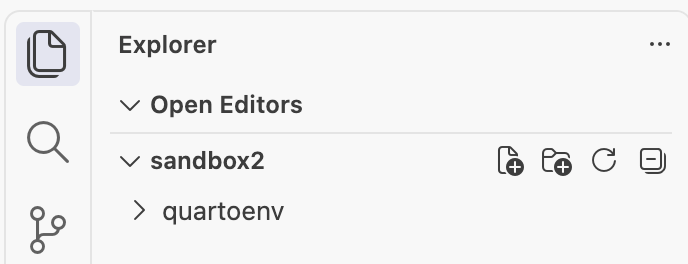

Give the file a name (e.g. `qmd-example.qmd`). Then paste the following content into the file (we will go through it below) and set the author name appropriately.

````
---
title: "My first Quarto document"
author: "Michael Stadler"
format: html
---

## Quarto

Quarto enables you to weave together content and executable code into a finished document. To learn more about Quarto see <https://quarto.org>.

## Running Code

When you click the **Render** button a document will be generated that includes both content and the output of embedded code. You can embed code like this:

```{python}
1 + 1
```

You can add options to executable code like this

```{python}
#| echo: false
2 * 2
```

The `echo: false` option disables the printing of code (only output is displayed).
````

# Rendering the document

```r
quarto::quarto_render("qmd-example.qmd")
```

More settings related to the rendering can be found by clicking on the little gear next to the Render button:

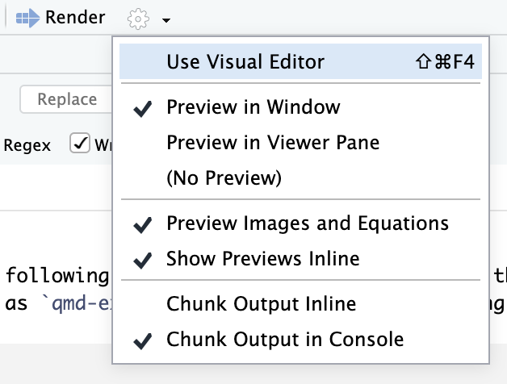

**Rendering an R Markdown document**

To render an R Markdown document, you can click the `Knit` button in RStudio, or type

```r
rmarkdown::render("rmd-example.rmd")
```

However, in this case there is an important difference between the two ways of rendering the document: clicking on the `Knit` button will render the document in a new R session, while `rmarkdown::render()` will by default execute the code in the document in the “parent environment” (the current active R session).

For now, let’s click on the `Render` button to generate an HTML file from our `.qmd` document.

**Python/Visual Studio Code**

The rendering is done in a very similar way to what we showed for RStudio above, the main difference being that the Jupyter engine is used instead of knitr to extract and evaluate the code chunks.

[figure not shown]

Source: https://quarto.org/docs/get-started/hello/vscode.html

# The YAML header

Now that we’ve tried the process of generating the output file, let’s take a look at the structure of the `.qmd` file. The first lines form the so called *YAML header* - this is where you specify what type of document you want to build from the `.qmd` file, and provide details about styles and themes. We can see that the template document generated by RStudio contains the information that we specified when creating the file.

```
---
title: "My first Quarto document"
author: "Michael Stadler"
format: html
---
```

If we want to change the output format, this can be done in the YAML header (i.e., there’s no need to create a new document from scratch). For example, if we want a PDF file (using LaTeX) rather than an HTML file, we change the last line in the YAML header to:

```
format: pdf
```

or if you have not installed LaTeX, you can use the built-in Typst using:

```
format: typst
```

We can configure many aspects of our document via the YAML fields. The available fields depend to some extent on the selected format. [This website](https://quarto.org/docs/reference/formats/html.html) lists the options available for HTML files.

In our example document, let’s add a table of contents and change the theme. You can find a list of available themes [here](https://quarto.org/docs/output-formats/html-themes.html). We will also add a line to make the HTML file *self-contained* (`embed-resources: true`). Without this line, any external dependencies of the HTML file (images, style sheets, etc) will be placed in a separate folder, which must be distributed along with the HTML file for proper rendering. A self-contained HTML file is larger, but can be shared or moved without external dependencies. Our YAML header will now look something like this (note the indentation under `format` - this is important for correct parsing of the YAML):

```
---
title: "My first Quarto document"
author: "Michael Stadler"
format:
    html:
        toc: true
        theme: cosmo
        embed-resources: true
---
```

Try to render the document again and see the difference. If the options that we specify should apply across any output format that we may want to use, we can also define them on the top level, rather than under the specific format. For example, if we would like to be able to render the document also into PDF format, and we would like to have a table of content also in that case, but the `cosmo` theme should only be used for the html format, this could be specified as follows:

```
---
title: "My first Quarto document"
author: "Michael Stadler"
toc: true
format:
    html:
        toc: true
        theme: cosmo
        embed-resources: true
    pdf: default
---
```

If we add multiple possible formats as in the example above, we can choose the rendering format in the little dropdown menu that then appears next to the ‘Render’ button:

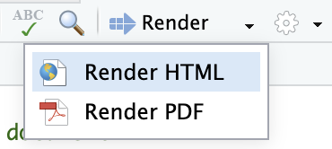

By default, the format that is specified first in the YAML will be used, and if you have already rendered it once, it will use that format again if you just click on the ‘Render’ button.

**Exercise**

Add a date to the YAML header. See [here](https://quarto.org/docs/reference/dates) for information about how to specify dates in Quarto.

**Solution - fixed date**

```
---
title: "My first Quarto document"
author: "Michael Stadler"
date: "2026-10-20"
date-format: "long"
format:
    html:
        toc: true
        theme: cosmo
        embed-resources: true
---
```

**Solution - using the date when the document is rendered (R code)**

```
---
title: "My first Quarto document"
author: "Michael Stadler"
date: "`r Sys.Date()`"
date-format: "long"
format:
    html:
        toc: true
        theme: cosmo
        embed-resources: true
---
```

**Solution - using the date when the document is rendered (`today` quarto keyword, does not work in R Markdown)**

```
---
title: "My first Quarto document"
author: "Michael Stadler"
date: today
date-format: "long"
format:
    html:
        toc: true
        theme: cosmo
        embed-resources: true
---
```

# The body of the document

Below the YAML header, the rest of the `.qmd` document consists of a mix of regular text and code chunks. The text is formatted according to [`markdown` syntax](https://quarto.org/docs/authoring/markdown-basics.html) (see also [this page](https://www.markdownguide.org/basic-syntax/)). For example, headers (of different levels) are generated by prepending (different numbers of) hash symbols (`#`) to the header text:

```
# Header 1
## Header 2
### Header 3
```

**Bold** **text** is obtained by adding `__` or `**` to each side of the text, and *italic* *text* is obtained by adding `_` or `*` to each side of the text.

Code chunks are generated with the following syntax:

````markdown
```{r}
x <- 1 + 1
```
````

**Tip**

On a Swiss QWERTZ keyboard, the backtick can be found here:

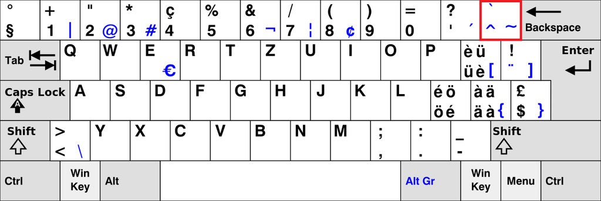

Source: https://superuser.com/questions/254076/how-do-i-type-the-tick-and-backtick-characters-on-windows

The `{r}` part indicates that the chunk contains R code. It is possible to use other engines (e.g., `python` or `bash`) by replacing the `r` in the chunk header (note that additional packages, as well as a functional python installation, may be required to, e.g., execute python code). Rather than explicitly typing the code chunk, we can use the keyboard shortcut `Ctrl`+`Alt`+`I` (or `Cmd`+`Option`+`I` on macOS) in RStudio. If we are using the `Visual` code editor in RStudio, chunks can be added by typing `/` and choosing the appropriate chunk type.

It is also useful to know that we can directly execute a line in a code chunk in the `.qmd` file by placing the cursor on the line and pressing `Ctrl`+`Enter` (or `Cmd`+`Enter` on macOS). A whole chunk can be executed by clicking on the little green arrow in the top right corner of the chunk. The grey arrow executes all chunks preceding the current chunk.

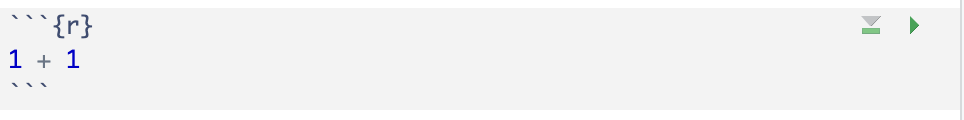

**Python/Visual Studio Code**

In Visual Studio Code, we can execute a code chunk by clicking on the `Run Cell` arrow above the chunk:

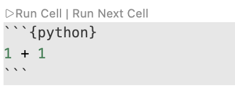

We can also use `Ctrl` + `Enter` (`Cmd` + `Enter` on macOS) or `Shift` + `Enter` to execute the chunk in an interactive python session.

We can also include inline R code, enclosed in single backticks: `` `{r} x + 1` `` (as for the code chunks, we can use different code engines here as well). This is useful e.g. if we want to refer to values of specific variables directly in the text. A frequent use of this syntax can be seen in the YAML header above - see how the current date was obtained by executing the R function `Sys.Date()`.

**Exercise**

Let’s now practice what we just learned. In your example `.qmd` document, add a suitable header and a code chunk where you print the first six rows of the built-in `iris` dataset. Below the code chunk, add a sentence where you include the number of observations (rows) in the `iris` dataset.

**Python/Visual Studio Code**

In python, the `iris` dataset is provided via the `scikit-learn` package:

````markdown
```{python}
from sklearn import datasets
iris = datasets.load_iris()["data"]
type(iris)
iris.shape
```
````

# Customizing code chunks

In addition to the language indicator, there are many other ways of customizing code chunks with so called ‘chunk options’. For example, we can decide whether the code should be evaluated at all, whether the code should be shown or hidden in the final report, and the size of any figures generated by the code. We can also add captions and alt-text for any displayed figures, for increased accessibility. Chunk options are specified inside the chunk, preceded by `#|`. For example, the code in the following chunk will be printed, but not executed:

````markdown
```{r}
#| echo: true
#| eval: false

1 + 1
```
````

For additional controls related to chunk execution, see [this page](https://quarto.org/docs/computations/execution-options.html). The options can also be set globally in the YAML header, under the `execute` directive. Specifications in a given chunk will override the global settings.

It is often useful to assign labels to the chunks. This makes it easier to navigate the document and find the source of any errors, and additionally means that any output figures generated in the document will be named according to the chunk where they were generated. In RStudio, you can navigate between sections and chunks in the lower left corner of the editor panel:

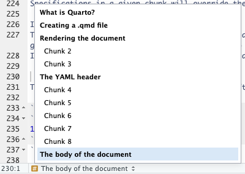

**Python/Visual Studio Code**

In VS Code, the document structure can be accessed via the three dots (`...`) at the top next to the file name:

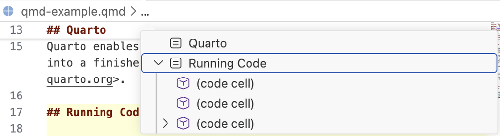

To label a chunk, add a suitable name as an option:

````markdown
```{r}
#| label: addition_chunk

1 + 1
```
````

# Markdown editing modes

**Python/Visual Studio Code**

In Visual Studio Code, we can switch mode by clicking on the three dots to the right of the Preview button, and choosing ‘Edit in Visual Mode’.

In ‘Visual’ mode, we can edit the document in a perhaps more intuitive way (or, at least, in a way that is more similar to the final rendered version). For example, adding headers can now be done by selecting the desired header level from a dropdown menu. We can swap between the two editing modes at any time. This can also be helpful in order to learn the markdown syntax for specific formatting options.

Remark: When you switch to the “Visual” mode, you may get a popup message that lets you confirm if you really want to switch. Switching is usually harmless but may entail a reformatting of the document, for example the placement of line breaks and indentation may change as a result.

# Parameterized reports

Sometimes, we have a template `.qmd` file from which we would like to generate multiple output files, each with a different value of a given parameter. A typical use-case for a parameterized report is the analysis of repeated experiments, in which all analysis are identical except for the parameter that defines the name of the input file with the measurement data. Instead of generating a separate `.qmd` file for each of these parameter values, we can make use of so called [*parameterized reports*](https://quarto.org/docs/computations/parameters.html). To parameterize your `.qmd` file, add a section in the YAML header defining the parameters that will be used, and provide a default value:

```
---
title: "My first Quarto document"
author: "Michael Stadler"
date: today
date-format: "long"
format:
    html:
        toc: true
        theme: cosmo
        embed-resources: true
params:
    species: "setosa"
---
```

You can then use the parameter anywhere in the document via the R syntax `params$species`. Any number of parameters can be specified in this way. Now, if the document is rendered via the `Render` button, the default value of each parameter will be used. To change the value, use the `quarto_render()` function from the `quarto` R package and specify the desired parameter values via the `execute_params` argument:

```r
quarto::quarto_render("qmd-example.qmd",
                      execute_params = list(species = "virginica"))
```

We can also set the name of the output file (we may want this to reflect the parameter value):

```r
quarto::quarto_render("qmd-example.qmd",
                      execute_params = list(species = "virginica"),
                      output_file = "virginica_report.html")
```

**Python/Visual Studio Code**

The Jupyter engine uses a different formulation of parameters than the knitr engine. With Jupyter, we create a chunk with the tag “parameters”, where we specify the parameter values

````markdown
```{python}
#| tags: [parameters]

species = "setosa"
```
````

These parameters are then available in the top-level environment. To change the parameters, we render the document from the command line:

```bash
quarto render qmd-example.qmd -P species:virginica
```

Note that this requires the `papermill` package.

**Exercise**

To practice this, let’s create a parameterized report where instead of printing the size of the entire `iris` dataset as we did above, we only print out the number of observations from the indicated species.

# Images

Images can be included in `.qmd` files using the following syntax:

```
![](path/to/image.png)
```

You can specify additional specifiers at the end of the inclusion expression:

```
![](path/to/image.png){width=90%}
```

(See [here](https://quarto.org/docs/authoring/figures.html) for additional supported specifiers.)

Alternatively, we can use `knitr`:

````markdown
```{r}
knitr::include_graphics("path/to/image.png")
```
````

Or directly HTML:

```
<img src="path/to/image.png" width="90%"/>
```

# Session info

In order to keep a record of the package versions used to generate a given output file, it is useful to include a code chunk providing the session information in the end of every `.qmd` file. Add the following to your example `.qmd`:

````markdown
```{r}
sessionInfo()
```
````

As a bonus, with a bit of HTML, we can even make it collapsible, to take less space but still be available if requested.

````markdown
<details>
<summary><b>
Session info
</b></summary>
```{r}
sessionInfo()
```
</details>
````

**Python/Visual Studio Code**

In python, we can print a session information using the `session_info` package.

````markdown
```{python}
import session_info
session_info.show()
```
````

# Combining Python and R in the same document

As mentioned before, Quarto documents may contain code chunks for several programming languages, including R, Python and bash. It is even possible to combine both R and Python in the same document and exchange data between the two interpreter processes, using the special variables `r` (from Python) or `py` (from R).

Here, we illustrate this by using RStudio and including an R code chunk at the beginning of the document that selects the Python environment to be used for the document. This functionality is provided by the [reticulate](https://rstudio.github.io/reticulate/) package:

````markdown
```{r}
# load R's reticulate library
library(reticulate)

# select the python virtual environment to use
use_virtualenv("./quartoenv")

# start the linked python process and print the python configuration
py_config()
```
````

**Selecting a suitable Python environment**

A few things should be considered when combining R and Python in a single document:

- Only a single Python environment can be selected in a given R session, i.e. you cannot switch between two Python environments in a single document.
- The above R code with `use_virtualenv()` or `py_config()` should be called before any `{python}` code chunks, otherwise a default Python environment or interpreter will already have been selected.
- If no Python environment exists yet and `uv` is available on the computer, it will be used to create an ephemeral environment for the document when Python is first used. For more details, see the [py_require() documentation](https://rstudio.github.io/reticulate/reference/py_require.html) or also the setup document for this course session.

After the above code chunk, you can mix R and Python code chunks in your Quarto document, by defining the language of a each chunk using the language indicater as before (`{r}` or `{python}`).

Through the special variables `r` (from Python) and `py` (from R), the linked R and Python processes can access objects from the other process, which are automatically translated according to [this table](https://rstudio.github.io/reticulate/articles/calling_python.html#type-conversions):

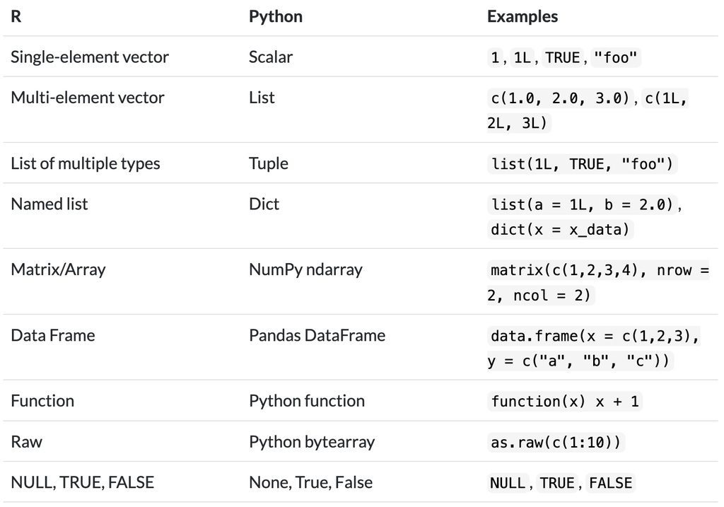

Here are some simple examples:

Access the R `iris` `data.frame` from Python:

````markdown
```{python}
type(r.iris)
```
````

Note that if Pandas is available in your Python environment, then this will be used to represent an R `data.frame`. Otherwise, it will be represented as a Python `dict`.

As a second example, we use `numpy` to create a 2-by-3 matrix filled with ones:

````markdown
```{r}
np <- reticulate::import("numpy")
np$ones(c(2L, 3L))
```
````

Finally, we create a list in Python and access it from R:

````markdown
```{python}
mylist = [0, 2, 4]
```
````

````markdown
```{r}
py$mylist
```
````

# Assembling figure panels within R

Using the workflow described above, we have a way to reproducibly generate figure panels starting from a suitably processed input data file. In this section, we will see how we can combine these panels into complete figures, which can be directly inserted into your manuscript. For this we will use the [`patchwork`](https://patchwork.data-imaginist.com/) R package. This is not the only R package that allows this type of workflow - you can also have a look at [`cowplot`](https://cran.r-project.org/web/packages/cowplot/vignettes/introduction.html). In python, there is a corresponding package [`patchworklib`](https://pypi.org/project/patchworklib/).

The idea behind these packages is that we create the individual figure panels as usual, and the use the capabilities of (e.g.) `patchwork` to assemble the panels in a suitable configuration.

Let’s look at an example. We start by creating three plots, using the built-in `iris` data set.

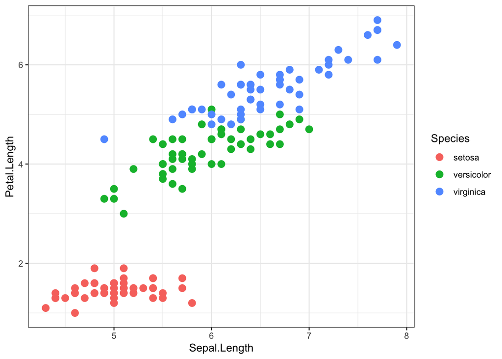

```r
library(ggplot2)
(p1 <- ggplot(iris, aes(x = Sepal.Length, y = Petal.Length)) +
    geom_point(size = 3, aes(color = Species)) +
    theme_bw())
```

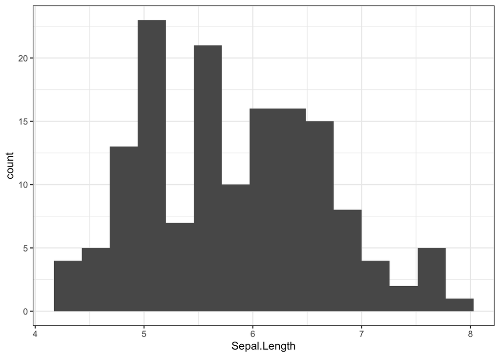

```r
(p2 <- ggplot(iris, aes(x = Sepal.Length)) +
    geom_histogram(bins = 15) +
    theme_bw())
```

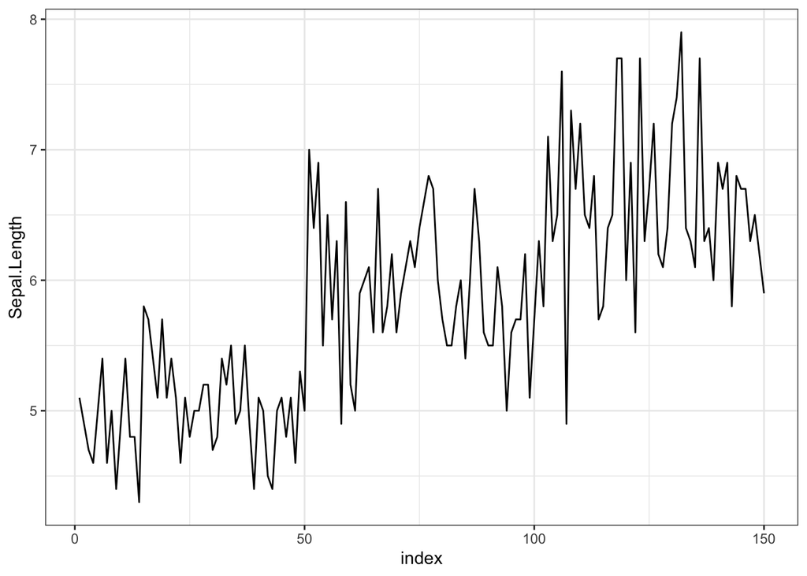

```r
(p3 <- ggplot(iris |> dplyr::mutate(index = seq_along(Petal.Length)),
              aes(x = index, y = Sepal.Length)) +
    geom_line() +
    theme_bw())
```

Next, we combine them into a single figure using `patchwork`. The `|` symbol is used when we want panels to appear next to each other, in the same row. The `/` symbol is used when we want panels to appear underneath each other, in the same column. `patchwork` will do its best to align the axes of the different panels as well as possible, to provide a nice and clean visualization.

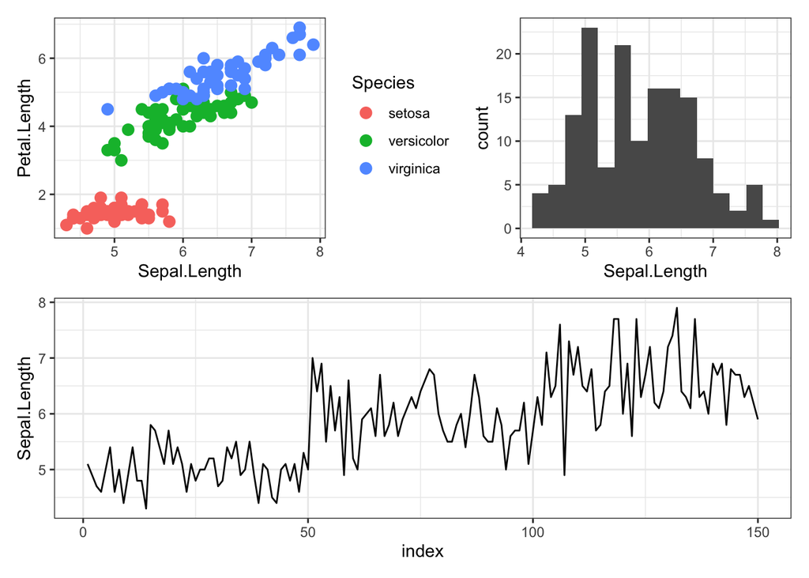

```r
library(patchwork)
(p1 | p2) / p3
```

`patchwork` works with base plots as well as plots generated using `ggplot2`.

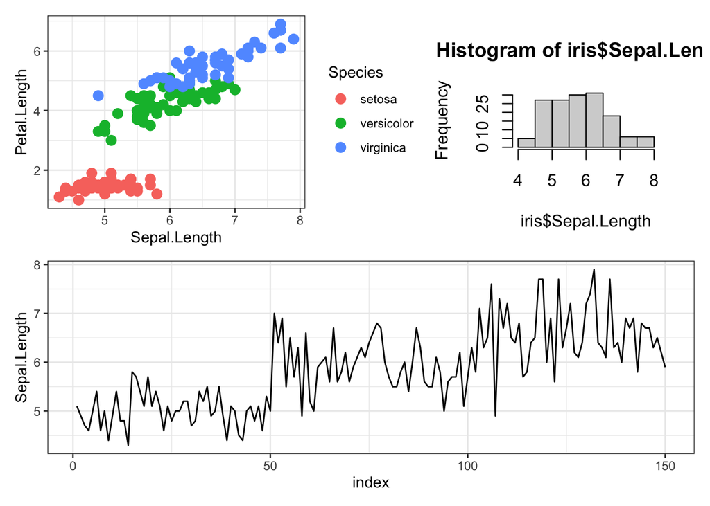

```r
(p1 | ~hist(iris$Sepal.Length)) / p3
```

We can also include pre-generated image files (e.g., in png format). This can be useful if we want to generate figures containing panels with schematics or other types of images that are not generated in R. One way to get such files into R and a format compatible with `patchwork` or `cowplot` is to use the `ggdraw()` and `draw_image()` functions from the `cowplot` package (does require also the `magick` package to be installed).

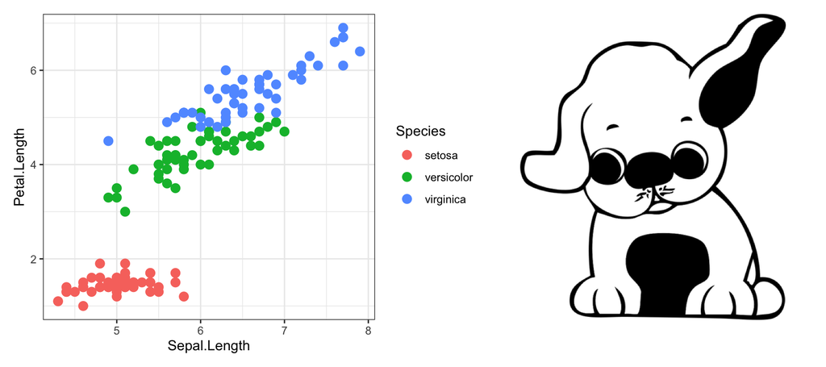

```r
puppy <- cowplot::ggdraw() +
    cowplot::draw_image("https://publicdomainvectors.org/photos/johnny_automatic_puppy.png")
p1 | puppy
```

We can also add a shared title, a caption, and labels for the individual panels. In this way, it is often possible to reproducibly generate figures that can be directly used in a publication.

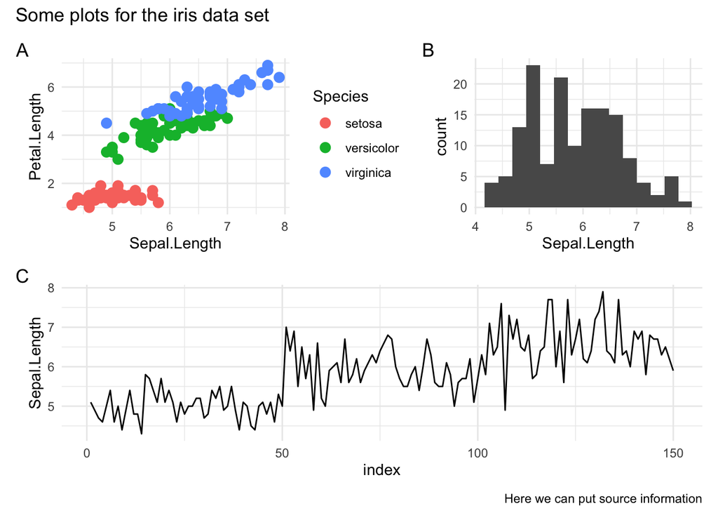

```r
p <- (p1 | p2) / p3
p + plot_annotation(
    title = "Some plots for the iris data set",
    caption = "Here we can put source information",
    tag_levels = 'A'
) &
    theme_minimal()
```

Many more examples and guidance can be found on the [patchwork website](https://patchwork.data-imaginist.com/).

# Reproducible publishing with journal templates

So far, we have seen how we can write reports and generate complete figures in a reproducible way. This type of reports could, for example, be used as supplementary material for a manuscript. To generate the actual manuscript file, we would still need to paste the results and the generated figures into the Word document that will be submitted to the journal. However, Quarto also provides [journal templates](https://quarto.org/docs/journals/) for several journals, which means that we can directly write our paper using literate programming, and submit the resulting Word/LaTeX/pdf file to the journal. If your favorite journal does not already have a template, you can also create your own. The setup makes it easy to change between different journal styles, still using the same underlying source file. This approach works well for “not-too-computational” manuscripts, where all computations can be run in a single file, and are sufficiently quick that it is not a problem to rerun them each time anything in the manuscript changes.

Let’s try this out - we’ll create an example journal article, using the style from the PLOS family of journals. Typing the following code into a terminal window will initialize a new `.qmd` file following this journal template style:

```bash
quarto use template quarto-journals/plos
```

The resulting file can then be edited and expanded upon like any other Quarto file. If you just want to install the journal format extension (without creating a new document), e.g. to use it in an existing document, you can do that by running the following code from within the target directory:

```bash
quarto add quarto-journals/plos
```

# Quarto Manuscripts

An even more comprehensive toolbox for publishing manuscripts is provided by the *Quarto Manuscripts* framework. Here, each Quarto manuscript is its own [Quarto project](https://quarto.org/docs/projects/quarto-projects.html) (not just a single file). The manuscript will be rendered in multiple formats, which can all be accessed via a generated website. Separate notebooks can also be used as a source of content and computations. Thus, this approach, while more complex than what we have seen before, is really aimed at producing fully reproducible manuscripts for projects involving lots of computation, perhaps in different languages, which can not all be re-executed every time the manuscript text changes.

An example can be seen [here](https://notebooks-now.github.io/submission-quarto-full/). To initialize such a manuscript, we have to create a Quarto project. This can be done from the command line as follows:

```bash
quarto create project manuscript my_awesome_manuscript
```

This will create a Quarto project in a new folder named `my_awesome_manuscript`, and you can further choose to open it in either RStudio or Visual Studio Code.

# Final tips

- Always include the session info.
- Avoid hardcoded absolute paths, they will make it impossible for someone else to reproduce your analysis.
- With parameterized reports, it’s helpful to print out the values of the parameters somewhere in the report for reproducibility purposes, as the final report may have been generated from the command line with parameter values different from the default ones contained in the source file.

# Conclusion

In this workshop, we have seen how we can use Quarto to generate reproducible reports containing both text, code and output. Of course this is not the only way to make analyses reproducible - done correctly, a regular script can be just as reproducible. One nice aspect of literate programming, however, is that you can be sure that if the document compiles, the code actually works, you will see exactly how each figure was generated, and there is no way to ‘leave out’ or miss any details. With a script, you need some level of trust that this was, in fact, the code that was used to generate the saved figures. In addition, there are many other aspects that are essential for reproducibility that we have not touched upon here, including making all data accessible, and if possible providing a reproducible software environment (for example, using python environments or docker images).

# Resources

- [RStudio keyboard shortcuts](https://bookdown.org/yihui/rmarkdown-cookbook/rstudio-shortcuts.html)
- [Quarto webpage](https://quarto.org/)
- [Quarto introductory tutorial](https://quarto.org/docs/get-started/hello/rstudio.html)
- [Quarto authoring guide](https://quarto.org/docs/get-started/authoring/rstudio.html)
- [More details about article layout in Quarto](https://quarto.org/docs/authoring/article-layout.html)
- [R Markdown cheat sheet from RStudio](https://rstudio.github.io/cheatsheets/rmarkdown.pdf)
- [R Markdown reference guide](https://github.com/duttashi/learnr/blob/master/resources/R-cheat-sheets/R%20Markdown%20Reference%20Guide.pdf)
- [R Markdown crash course](https://zsmith27.github.io/rmarkdown_crash-course/index.html)
- [R Markdown website](https://rmarkdown.rstudio.com/)
- [Lessons on R Markdown](https://rmarkdown.rstudio.com/lesson-1.html)
- [R Markdown - the definitive guide](https://bookdown.org/yihui/rmarkdown/)
- [R Markdown cookbook](https://bookdown.org/yihui/rmarkdown-cookbook/)
- [Blog post on Quarto vs Rmarkdown](https://yihui.org/en/2022/04/quarto-r-markdown/#:~:text=For%20R%20users%2C%20Quarto%20uses,implementation%20of%20figure%20cross%2Dreferences.)
- [Quarto/R Markdown - what’s different](https://laderast.github.io/qmd_rmd/#/title-slide)
- [Reticulate: R Interface to Python](https://rstudio.github.io/reticulate/index.html)
- [Quarto extensions - journal articles](https://quarto.org/docs/extensions/listing-journals.html)
- [Reproducible manuscripts with Quarto (talk by JJ Allaire)](https://jjallaire.quarto.pub/reproducible-manuscripts-with-quarto/#/title-slide)
- [Quarto webR extension for building interactive websites](https://quarto-webr.thecoatlessprofessor.com/)
- [Hello Quarto! Keynote from rstudio::conf(2022)](https://www.youtube.com/watch?v=p7Hxu4coDl8)
- [Quarto introduction in R4DS book](https://r4ds.hadley.nz/quarto)
- [A Primer on dynamic reporting](https://zenodo.org/records/8354360)
- [Reproducible manuscripts with Quarto (talk by Mine Cetinkaya-Rundel)](https://mine.quarto.pub/manuscripts-conf23/#/title-slide)